# 1.实验设计

对NAFnet的NAFBlock进行改进，将所有提升通道数的conv2d替换为fwht_expansion。

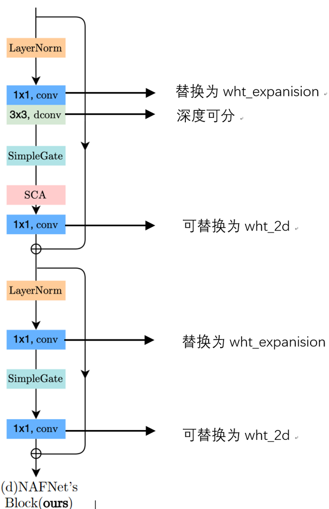

# 2.网络结构

NAFnet的网络结构、NAFnetBlock的模块结构、WHT_expansion的模块结构。

```python
class NAFNet(nn.Module):
    def __init__(self, img_channel=3, width=16, middle_blk_num=1, enc_blk_nums=[], dec_blk_nums=[] , size=256):
        super().__init__()
        self.intro = nn.Conv2d(in_channels=img_channel, out_channels=width, kernel_size=3, padding=1, stride=1, groups=1,bias=True)
        self.ending = nn.Conv2d(in_channels=width, out_channels=img_channel, kernel_size=3, padding=1, stride=1, groups=1,bias=True)
        self.encoders = nn.ModuleList()
        self.decoders = nn.ModuleList()
        self.middle_blks = nn.ModuleList()
        self.ups = nn.ModuleList()
        self.downs = nn.ModuleList()
        chan = width
        for num in enc_blk_nums:
            self.encoders.append(nn.Sequential(*[NAFBlock(chan) for _ in range(num)]))
            self.downs.append(nn.Conv2d(chan, 2*chan, 2, 2))
            chan = chan * 2
        self.middle_blks = nn.Sequential(*[NAFBlock(chan) for _ in range(middle_blk_num)])
        for num in dec_blk_nums:
            self.ups.append(nn.Sequential(nn.Conv2d(chan, chan * 2, 1, bias=False),nn.PixelShuffle(2)))
            chan = chan // 2
            self.decoders.append(nn.Sequential(*[NAFBlock(chan) for _ in range(num)]))
        self.padder_size = 2 ** len(self.encoders)

    def forward(self, inp):
        B, C, H, W = inp.shape
        inp = self.check_image_size(inp)
        x = self.intro(inp)
        encs = []
        for encoder, down in zip(self.encoders, self.downs):
            x = encoder(x)
            encs.append(x)
            x = down(x)
        x = self.middle_blks(x)
        for decoder, up, enc_skip in zip(self.decoders, self.ups, encs[::-1]):
            x = up(x)
            x = x + enc_skip
            x = decoder(x)
        x = self.ending(x)
        x = x + inp
        return x[:, :, :H, :W]
```

```python
class NAFBlock(nn.Module):
    def __init__(self, c, DW_Expand=2, FFN_Expand=2, drop_out_rate=0.):
        super().__init__()
        dw_channel = c * DW_Expand
        #对conv1进行whtexpansion替换
#       self.conv1 = nn.Conv2d(in_channels=c, out_channels=dw_channel, kernel_size=1, padding=0, stride=1, groups=1, bias=True)
        self.conv1 = WHT_expansion(input_features = c , output_features = dw_channel)
        self.conv2 = nn.Conv2d(in_channels=dw_channel, out_channels=dw_channel, kernel_size=3, padding=1, stride=1, groups=dw_channel,bias=True)
        self.conv3 = nn.Conv2d(in_channels=dw_channel // 2, out_channels=c, kernel_size=1, padding=0, stride=1, groups=1, bias=True)
        # Simplified Channel Attention
        self.sca = nn.Sequential(
            nn.AdaptiveAvgPool2d(1),
            nn.Conv2d(in_channels=dw_channel // 2, out_channels=dw_channel // 2, kernel_size=1, padding=0, stride=1,
                      groups=1, bias=True),
        )
        # SimpleGate
        self.sg = SimpleGate()
        ffn_channel = FFN_Expand * c
        #对conv4进行whtexpansion替换
#         self.conv4 = nn.Conv2d(in_channels=c, out_channels=ffn_channel, kernel_size=1, padding=0, stride=1, groups=1, bias=True)
        self.conv4 = WHT_expansion(input_features = c , output_features = ffn_channel)
        self.conv5 = nn.Conv2d(in_channels=ffn_channel // 2, out_channels=c, kernel_size=1, padding=0, stride=1, groups=1, bias=True)
        self.norm1 = LayerNorm2d(c)
        self.norm2 = LayerNorm2d(c)
        self.dropout1 = nn.Dropout(drop_out_rate) if drop_out_rate > 0. else nn.Identity()
        self.dropout2 = nn.Dropout(drop_out_rate) if drop_out_rate > 0. else nn.Identity()
        self.beta = nn.Parameter(torch.zeros((1, c, 1, 1)), requires_grad=True)
        self.gamma = nn.Parameter(torch.zeros((1, c, 1, 1)), requires_grad=True)
    def forward(self, inp):
        x = inp
        x = self.norm1(x)
        x = x.permute(0,3,2,1)
        x = self.conv1(x)#替换为wht
        x = x.permute(0,3,2,1)
        x = self.conv2(x)
        x = self.sg(x)
        x = x * self.sca(x)
        x = self.conv3(x)
        x = self.dropout1(x)
        y = inp + x * self.beta
        x = self.norm2(y)
        x = x.permute(0,3,2,1)
        x = self.conv4(x)#替换为wht
        x = x.permute(0,3,2,1)
        x = self.sg(x)
        x = self.conv5(x)
        x = self.dropout2(x)
        return y + x * self.gamma
```

```python
class WHT_expansion(torch.nn.Module):
    """
    通道数扩展
    num_features: Length of the last axis, should be interger power of 2. If not, we pad 0s.
    residual: Apply shortcut connection or not
    retain_DC: Retain DC channel (the first channel) or not
    """
    def __init__(self, input_features , output_features , residual=False , retain_DC=True):
        super().__init__()
        self.input_features = input_features
        self.output_features = output_features
        self.num_features_pad = find_min_power(self.output_features)
        self.ST = SoftThresholding(self.num_features_pad)
        self.residual = residual
        self.retain_DC = retain_DC
    def forward(self, x):
        input_features = x.shape[-1]
        if input_features!= self.input_features:
            raise Exception('{}!={}'.format(input_features, self.input_features))
        if self.num_features_pad>input_features:
            f0 = torch.nn.functional.pad(x, (0, self.num_features_pad-input_features))
        else:
            f0 = x
        f1 = hadamard_transform(f0)
        f3 = self.ST(f1)
        # 如果需要，添加直流分量
        if self.retain_DC:
            f3[..., 0] = f1[..., 0]  # 恢复直流分量
        f4 = hadamard_transform(f3)
        y = f4[..., :self.output_features]
        if self.residual:
            y = y + x
        return y
```

# 3.实验结果(SIDD)

## 3.1模型参数

在同样的模型参数文件NAFNet-width64.yml下进行训练与测试，唯一的区别在于训练的epoch减半为50个。  
wht-NAFnet可训练参数量 5326 4963(203.4 M)  
原始NAFnet可训练参数量1 1598 2915(443M)

## 3.2训练loss

PSNRLoss是负数的https://github.com/megvii-research/NAFNet/issues/48

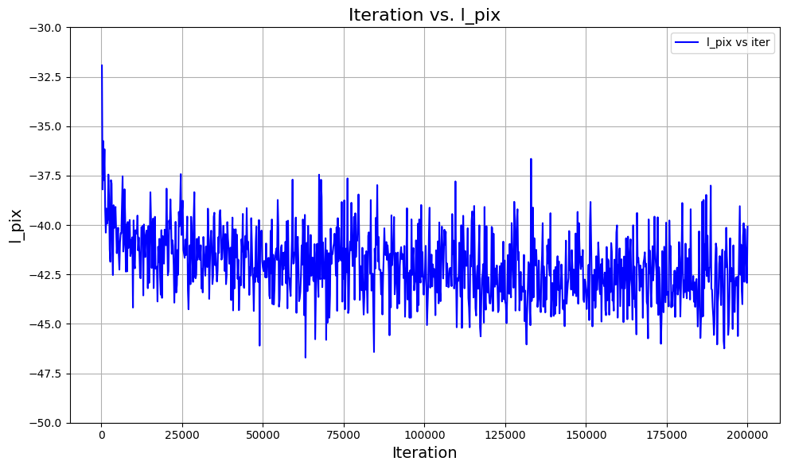

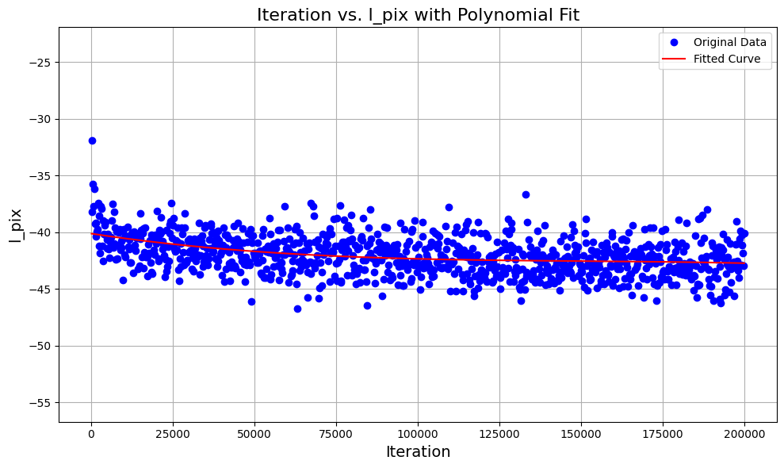

```python
import re
import matplotlib.pyplot as plt

# 正则表达式来提取信息
pattern = r"epoch:\s*(\d+)\s*,\s*iter:\s*([\d,]+)\s*,.*l_pix:\s*(-?\d+\.\d+e[+-]\d+|\-?\d+\.\d+)"

# 用于存储 iter 和 l_pix 的数据
iters = []
l_pix_values = []

# 打开 .log 文件并逐行读取
log_file_path = './experiments/NAFNet-SIDD-width64/train_NAFNet-SIDD-width64_20241101_213614.log'  # 替换为你的 .log 文件路径
with open(log_file_path, 'r') as file:
    for line in file:
        match = re.search(pattern, line)
        if match:
            iter_value = match.group(2).replace(',', '')  # 去除逗号，转换成纯数字
            l_pix = float(match.group(3))  # 将 l_pix 转换为浮动类型
            iters.append(int(iter_value))  # 将 iter 存入列表
            l_pix_values.append(l_pix)     # 将 l_pix 存入列表

# 绘制折线图
plt.figure(figsize=(10, 6))
plt.plot(iters, l_pix_values, linestyle='-', color='b', label='l_pix vs iter')

# 设置标题和标签
plt.title('Iteration vs. l_pix', fontsize=16)
plt.xlabel('Iteration', fontsize=14)
plt.ylabel('l_pix', fontsize=14)
plt.ylim(-50, -30)
plt.grid(True)
plt.legend()

# 显示图形
plt.tight_layout()
plt.show()

# 转换为 numpy 数组，方便后续处理
iters = np.array(iters)
l_pix_values = np.array(l_pix_values)

# 使用 3 阶多项式拟合数据
coefficients = np.polyfit(iters, l_pix_values, 3)

# 生成拟合曲线（使用拟合的系数生成一个多项式函数）
polynomial = np.poly1d(coefficients)

# 生成平滑的拟合曲线数据
smooth_x = np.linspace(min(iters), max(iters), 500)  # 使用更多的点来绘制平滑曲线
smooth_y = polynomial(smooth_x)

# 绘制原始数据点
plt.figure(figsize=(10, 6))
plt.plot(iters, l_pix_values, 'o', label='Original Data', color='b')

# 绘制拟合后的平滑曲线
plt.plot(smooth_x, smooth_y, '-', label='Fitted Curve', color='r')

# 设置标题和标签
plt.title('Iteration vs. l_pix with Polynomial Fit', fontsize=16)
plt.xlabel('Iteration', fontsize=14)
plt.ylabel('l_pix', fontsize=14)
plt.grid(True)

# 扩大纵轴范围，保持足够的空间
plt.ylim(min(l_pix_values) - 10, max(l_pix_values) + 10)

# 添加图例
plt.legend()

# 显示图形
plt.tight_layout()
plt.show()
```

```python
import re

# 定义正则表达式来匹配psnr和ssim值
pattern = r'# psnr:\s*([\d.]+)\s+# ssim:\s*([\d.]+)'

# 打开log文件并逐行读取
with open('./experiments/NAFNet-SIDD-width64/train_NAFNet-SIDD-width64_20241101_213614.log', 'r') as file:
    for line in file:
        # 使用正则表达式搜索匹配项
        match = re.search(pattern, line)
        if match:
            psnr = match.group(1)  # 提取psnr值
            ssim = match.group(2)  # 提取ssim值
            print(f"PSNR: {psnr}, SSIM: {ssim}")
```

```
PSNR: 35.1258, SSIM: 0.9090
PSNR: 38.8061, SSIM: 0.9514
PSNR: 39.0542, SSIM: 0.9539
PSNR: 39.1414, SSIM: 0.9542
PSNR: 39.2404, SSIM: 0.9548
PSNR: 39.1863, SSIM: 0.9555
PSNR: 39.4037, SSIM: 0.9565
PSNR: 39.3616, SSIM: 0.9563
PSNR: 39.4289, SSIM: 0.9567
PSNR: 39.4434, SSIM: 0.9564
PSNR: 39.5413, SSIM: 0.9572
PSNR: 39.5413, SSIM: 0.9572
```

## 3.3测试结果

### 3.3.1测试集测试指标结果

本次训练wht-NAFnet指标 # psnr: 39.5413 # ssim: 0.9572  
NAFnet放出的pretarin指标 # psnr: 40.3045 # ssim: 0.9614

### 3.3.2单个图片去噪对比

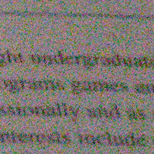

测试用原版图片

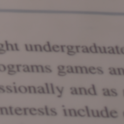

推测为PSNR40.3045，SSIM0.9614的pretrain模型去噪的图片

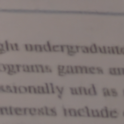

本次训练wht-NAFnet模型去噪的图片

# 4.思考

1、训练时是否一定需要使用蝶式算法？因为在GPU上训练使用矩阵计算会快很多，如果不是必须使用的话在训练时使用矩阵计算，在推理时使用蝶式算法会节省很多训练时间。  
2、本次训练模型的测试结果可能是由于训练总次数减半导致的，可以在此模型基础上继续训练。  
3、wht-mobilenetV2论文中提到模型前端的卷积层不适合用wht层代替。

# 5.TODO

1、在已有wht模型基础上继续训练。  
2、与wht并行的研究非对称卷积替换3×3卷积在NAFnet上的应用。